# Spatial Cueing Experiments

Pierce Edmiston

April 17, 2015

```
## [1] "Compiling raw data..."
## [1] "Coding variables..."
## [1] "Dropping practice trials..."
```

# Methods

## Participants

```
## Source: local data frame [4 x 3]
## Groups: interval [?]
##
##   interval flicker     n
##      (dbl)   (chr) (int)
## 1     0.10     off    10
## 2     0.10      on    16
## 3     0.75     off    20
## 4     0.75      on    32
```

## Analysis

Fit a model to predict accuracy following each cue type in each experiment condition. `flicker` and `interval` were varied between-subjects. `cue type` was varied within-subjects. Trials were evenly distributed between frame cues, sound cues, and no cue baseline trials. To estimate the effect of each cue (frame, sound) relative to baseline performance, two contrast variables were created. These contrast variables (`frame_v_nocue` and `sound_v_nocue`) are interpreted as the independent cueing effects of frames and sounds.

We are testing the hypothesis that the cueing effects are differentially affected by the flicker and interval manipulations. In particular, we expect the `frame_v_nocue` cueing effect to be more affected by the flicker manipulation than the `sound_v_nocue` cueing effect.

The contention is that it is only in a relatively small window of conditions that visual cues “outperform” so-called endogenous cues. For a majority of the visual tasks in our everyday lives, we are constantly confronted by irrelevant information and distractions. When there are distractions, such as a flickering visual mask, exogenous cues are not as effective for achieving heightened visual awareness.

# Results

## Cueing effects on accuracy

```
## Generalized linear mixed model fit by maximum likelihood (Laplace
##   Approximation) [glmerMod]
##  Family: binomial  ( logit )
## Formula:
## is_correct ~ (frame_v_nocue + sound_v_nocue) * (flicker_c + interval_c) +
##     (frame_v_nocue + sound_v_nocue || subj_id)
##    Data: cueing
##
##      AIC      BIC   logLik deviance df.resid
##  11437.2  11536.1  -5706.6  11413.2    27966
##
## Scaled residuals:
##      Min       1Q   Median       3Q      Max
## -15.9963   0.1025   0.1881   0.2768   0.8754
##
## Random effects:
##  Groups    Name          Variance Std.Dev.
##  subj_id   (Intercept)   0.99764  0.9988
##  subj_id.1 frame_v_nocue 0.03732  0.1932
##  subj_id.2 sound_v_nocue 0.07333  0.2708
## Number of obs: 27978, groups:  subj_id, 78
##
## Fixed effects:
##                          Estimate Std. Error z value Pr(>|z|)
## (Intercept)               3.36891    0.14305  23.551  < 2e-16 ***
## frame_v_nocue            -0.08268    0.08813  -0.938   0.3482
## sound_v_nocue             0.64422    0.11524   5.590 2.27e-08 ***
## flicker_c                 1.88012    0.26977   6.969 3.18e-12 ***
## interval_c               -0.31604    0.26394  -1.197   0.2311
## frame_v_nocue:flicker_c  -0.82174    0.17047  -4.820 1.43e-06 ***
## frame_v_nocue:interval_c  0.09727    0.14439   0.674   0.5005
## sound_v_nocue:flicker_c  -0.41181    0.20661  -1.993   0.0462 *
## sound_v_nocue:interval_c -0.15488    0.17831  -0.869   0.3851
## ---
## Signif. codes:  0 '***' 0.001 '**' 0.01 '*' 0.05 '.' 0.1 ' ' 1
##
## Correlation of Fixed Effects:
##             (Intr) frm_v_ snd_v_ flckr_ intrv_ frm_v_nc:f_ frm_v_nc:n_
## frame_v_noc -0.331
## sound_v_noc -0.255  0.391
## flicker_c    0.342 -0.226 -0.179
## interval_c  -0.311  0.095  0.065  0.019
## frm_v_nc:f_ -0.235  0.565  0.274 -0.334  0.009
## frm_v_nc:n_  0.109 -0.354 -0.127  0.012 -0.245 -0.014
## snd_v_nc:f_ -0.179  0.271  0.606 -0.261 -0.001  0.401      -0.011
## snd_v_nc:n_  0.081 -0.132 -0.358  0.003 -0.189 -0.008       0.333
##             snd_v_nc:f_
## frame_v_noc
## sound_v_noc
## flicker_c
## interval_c
## frm_v_nc:f_
## frm_v_nc:n_
## snd_v_nc:f_
## snd_v_nc:n_  0.013
## convergence code: 0
## Model failed to converge with max|grad| = 0.00345441 (tol = 0.001, component 1)
```

```
##   flicker interval exp
## 1      on     0.75   1
## 2     off     0.75   2
## 3      on     0.10   3
## 4     off     0.10   4
```

```
## Source: local data frame [8 x 7]
##
##            term   estimate  std.error statistic      p.value flicker
##           (chr)      (dbl)      (dbl)     (dbl)        (dbl)  (fctr)
## 1 frame_v_nocue  0.3087684 0.07640032  4.041455 5.312068e-05      on
## 2 sound_v_nocue  0.7462520 0.09624054  7.754029 8.902174e-15      on
## 3 frame_v_nocue -0.2461463 0.18305648 -1.344647 1.787393e-01     off
## 4 sound_v_nocue  0.5179985 0.26335755  1.966902 4.919451e-02     off
## 5 frame_v_nocue  0.4154017 0.15191080  2.734511 6.247302e-03      on
## 6 sound_v_nocue  0.9601126 0.15548151  6.175092 6.612504e-10      on
## 7 frame_v_nocue -1.0101823 0.32429676 -3.114993 1.839490e-03     off
## 8 sound_v_nocue  0.7226749 0.69843460  1.034707 3.008059e-01     off
## Variables not shown: interval (dbl)
```

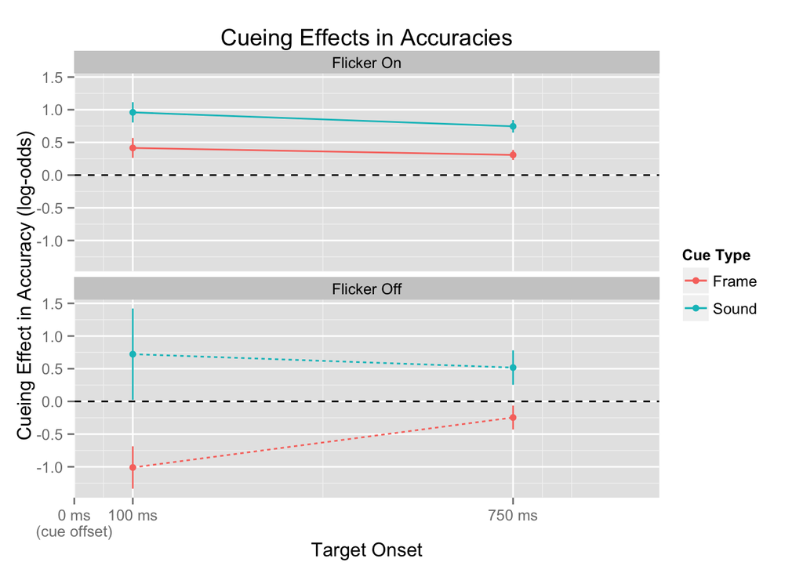

## Cueing effects on reaction times

```
## Linear mixed model fit by REML ['lmerMod']
## Formula:
## rt ~ (frame_v_nocue + sound_v_nocue) * (flicker_c + interval_c) +
##     ((1 | subj_id) + (0 + frame_v_nocue | subj_id) + (0 + sound_v_nocue |
##         subj_id))
##    Data: hits
##
## REML criterion at convergence: 279991.5
##
## Scaled residuals:
##     Min      1Q  Median      3Q     Max
## -4.8912 -0.4787 -0.1272  0.3409  7.3106
##
## Random effects:
##  Groups    Name          Variance Std.Dev.
##  subj_id   (Intercept)    2561.9   50.62
##  subj_id.1 frame_v_nocue  1391.2   37.30
##  subj_id.2 sound_v_nocue   597.4   24.44
##  Residual                14424.7  120.10
## Number of obs: 22514, groups:  subj_id, 78
##
## Fixed effects:
##                          Estimate Std. Error t value
## (Intercept)               439.427      6.412   68.53
## frame_v_nocue             -38.145      5.058   -7.54
## sound_v_nocue             -43.511      3.688  -11.80
## flicker_c                -113.431     12.132   -9.35
## interval_c                 12.404     12.521    0.99
## frame_v_nocue:flicker_c    37.492      9.579    3.91
## frame_v_nocue:interval_c   24.672      9.880    2.50
## sound_v_nocue:flicker_c     6.551      6.987    0.94
## sound_v_nocue:interval_c    5.500      7.211    0.76
##
## Correlation of Fixed Effects:
##             (Intr) frm_v_ snd_v_ flckr_ intrv_ frm_v_nc:f_ frm_v_nc:n_
## frame_v_noc -0.071
## sound_v_noc -0.098  0.124
## flicker_c    0.216 -0.013 -0.018
## interval_c  -0.324  0.022  0.030 -0.001
## frm_v_nc:f_ -0.013  0.215  0.022 -0.072  0.001
## frm_v_nc:n_  0.022 -0.322 -0.038  0.001 -0.072 -0.003
## snd_v_nc:f_ -0.018  0.022  0.210 -0.099  0.001  0.125      -0.002
## snd_v_nc:n_  0.030 -0.038 -0.320  0.001 -0.099 -0.002       0.126
##             snd_v_nc:f_
## frame_v_noc
## sound_v_noc
## flicker_c
## interval_c
## frm_v_nc:f_
## frm_v_nc:n_
## snd_v_nc:f_
## snd_v_nc:n_  0.000
```

```
## Source: local data frame [8 x 6]
##
##            term   estimate std.error statistic flicker interval
##           (chr)      (dbl)     (dbl)     (dbl)  (fctr)    (dbl)
## 1 frame_v_nocue -42.958060  8.077621 -5.318157      on     0.75
## 2 sound_v_nocue -44.647847  6.387990 -6.989342      on     0.75
## 3 frame_v_nocue  -9.724096  6.651026 -1.462044     off     0.75
## 4 sound_v_nocue -36.427853  5.217036 -6.982480     off     0.75
## 5 frame_v_nocue -72.280261 12.220930 -5.914465      on     0.10
## 6 sound_v_nocue -48.126784  6.732705 -7.148209      on     0.10
## 7 frame_v_nocue -26.687612 10.326801 -2.584306     off     0.10
## 8 sound_v_nocue -45.139452  8.782150 -5.139909     off     0.10
```

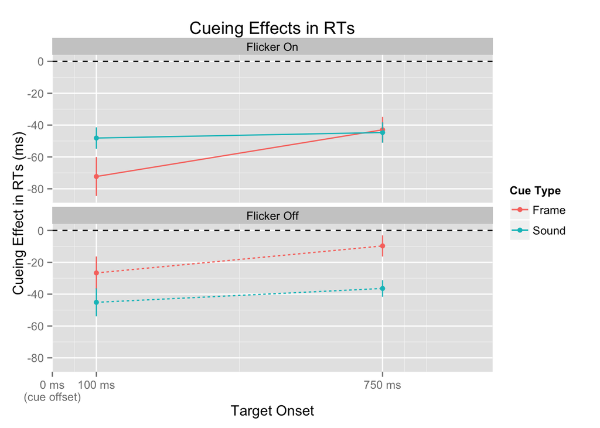

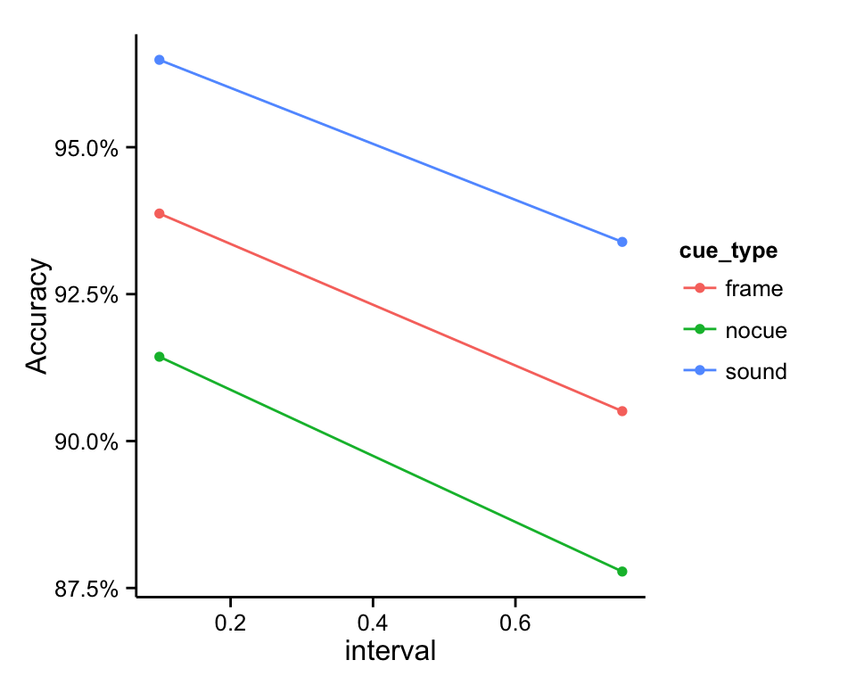

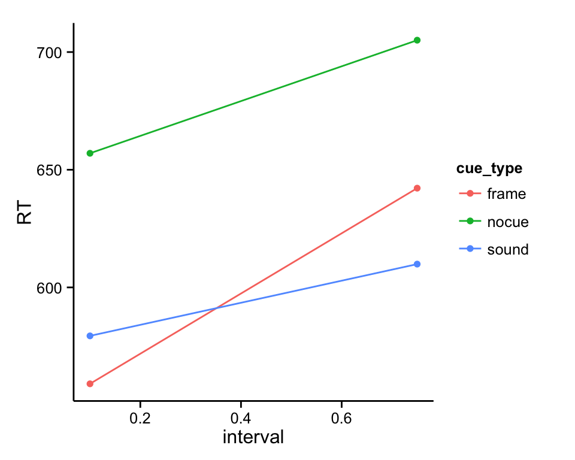

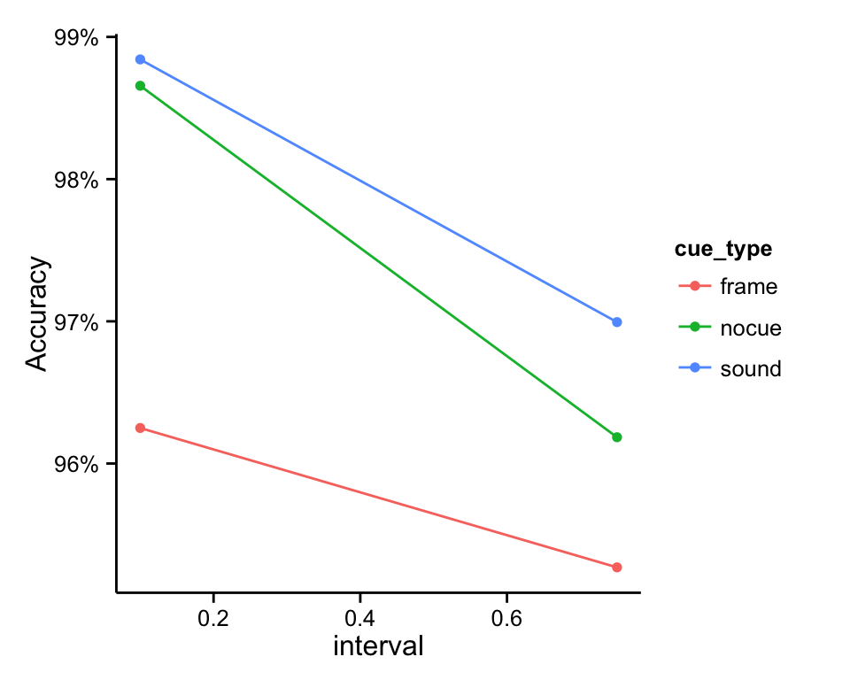

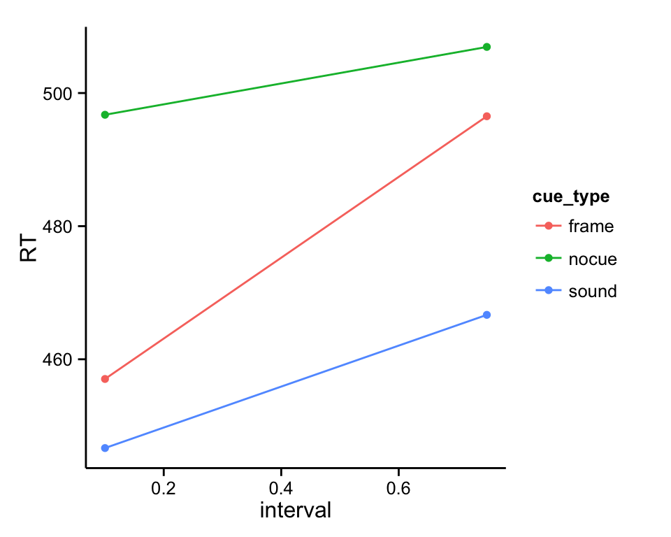

# Discussion

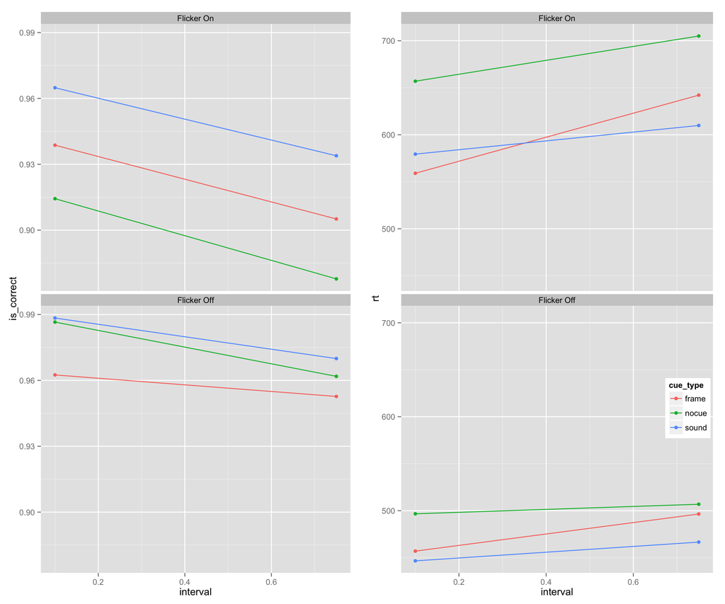

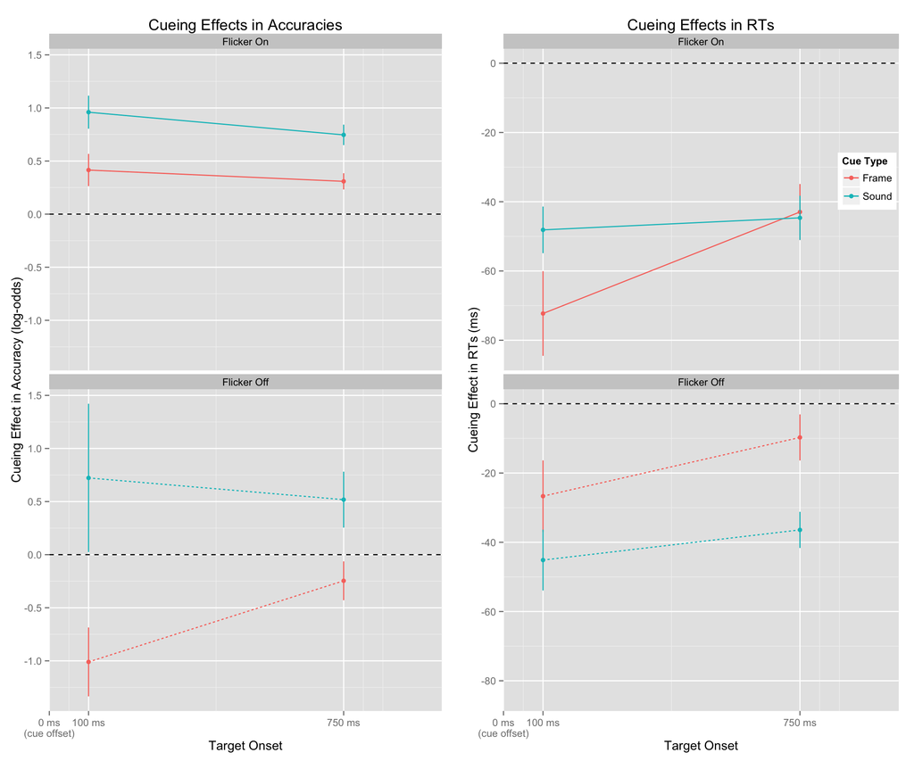

The experiments reported here do not establish why exogenous and endogenous cues differ in this way, a question to be addressed in future work. They do, however, motivate that work.

Traditionally, the difference between exogenous and endogenous cues has been attributed to time. Exogenous cues are faster acting than endogenous cues. There is also an element of volition: exogenous cues are automatic, whereas endogenous cues can be discounted.

But an implicit assumption in the literature is that controlling for these other factors, exogenous and endogenous cues can mean roughly the same thing when it comes to cueing a particular spatial location. Under the hood it is the same “spotlight of attention” in both cueing conditions.